# Tombstone Recessions Related to Atmospheric Sulfur Dioxide Concentrations

Paul Gilbert

22 April, 2020

# Tombstone Recession

[figure not shown]

Tombstone recession is a large problem in marble tombstones and has resulted in the loss of the final marker of the deceased.Thomas Meierding (1993) and his associates relate this recession with atmospheric $SO_2$ concentrations from the burning of fossil fuels (mostly coals).

# Weathering of Carbonate Rocks

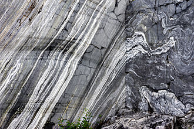

Marble Rock Face (Wikipedia)

- Marble
  - Metamorphosed Limestone
  - Highly Soluble (especially in presence of acids)
  - Limestone is rock type that forms caverns and sinkholes

# Weathering of Carbonate Rocks

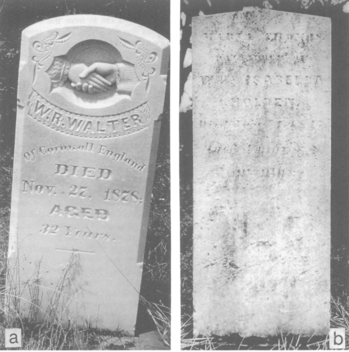

Tombstone Recession (Meierding, 1993)

- Sulphur Dioxide
  - Acidic compound released from the burning of coal
  - Conjoins meteroic waters to form sulphuric acid
  - Bonds with calcite in marble to form expanding gypsum
    - Results in granular breakage and loss

# Data Table of $SO_2$ Content and Recession

|  | Location | SO2 | Recession |
| --- | --- | --- | --- |
| 1 | Washington, DC (rural) | 12 | 0.27 |
| 2 | Cincinnati, OH (Rural) | 20 | 0.14 |
| 3 | Philadelphia, PA (Rural) | 20 | 0.33 |
| 4 | Richmond, VA | 46 | 0.81 |
| 5 | Fall River, MA | 48 | 0.84 |
| 6 | Hartford,CT | 92 | 1.08 |
| 7 | Evanston,IL | 91 | 1.78 |
| 8 | Albany,NY | 94 | 1.21 |
| 9 | Washington,DC | 102 | 1.09 |
| 10 | Louisville,KY | 117 | 1.72 |

[output cut: 11 more lines]

# Plot of $SO_2$ Content vs. Recession

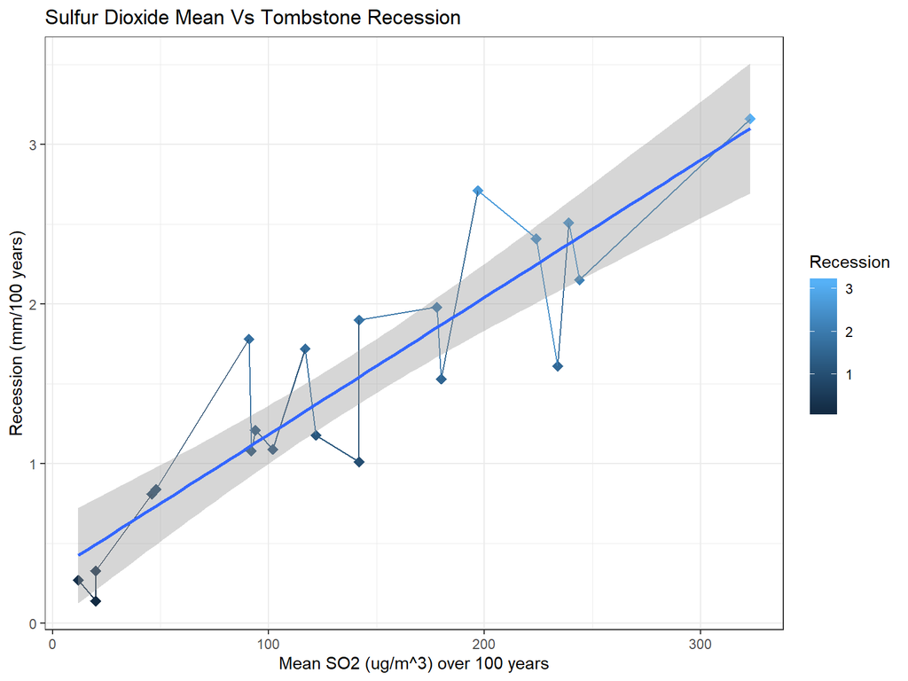

# Simple Linear Regression

Using specific assuptions about $\epsilon$ as laid out by Mendenhall and Sincich (2016), we will estimate the parameters $\beta_0$ and $\beta_1$.

# Method of Least Squares

The method of least squares allows us to use an equation that gives us a line that has a smaller sum of squares than any other straight line model. Originally, our equation for a straight line model is
$$y=\beta_0 +
\beta_1x+\epsilon$$
Our estimators will not include $\epsilon$. So it will be equal to
$$\hat{y}=\hat{\beta}_0 +
\hat{\beta}_1x$$
The deviation of the ith value from y is called a residual and is defined by:
$$(y_i-\hat{y}_i)=[y_i-(\hat{\beta}_0+\hat{\beta}_1x_i)]$$
So using the least squares method, this brings us to our line equation that uses $\hat{\beta}_0 \quad and \quad \hat{\beta}_1$ to minimize the equation:
$$SSE=\sum_{i=1}^n[y_i-(\hat{\beta}_0+\hat{\beta}_1x_i)]^2$$

# Estimators of $\beta_0$ and $\beta_1$

```r
tb.lm=with(tb, lm(re~so))
print(coef(tb.lm))
```

```
## (Intercept)          so
## 0.322995899 0.008593333
```

Using the code above we have created a linear model with our data. This will give us slope and intercept coordinates. Using this information we can see that
$$\hat{\beta}_0=0.322996$$
$$\hat{\beta}_1=0.008593$$

### 95% Confidence Interval of Estimates

```r
ciReg(tb.lm, conf.level=0.95, print.out=TRUE)
```

```
##             95 % C.I.lower    95 % C.I.upper
## (Intercept)        0.00445           0.64155
## so                 0.00661           0.01058
```

Our confidence interval for $\hat{\beta}_0$ is [0.00445, 0.64155]. Our confidence interval for $\hat{\beta}_1$ is [0.00661, 0.01058].

Using our intitial estimate equation $\hat{y}=\hat{\beta}_0+\hat{\beta}_1x_i$ with our estimators we get:
$$\hat{y}=\hat{\beta}_0 +
\hat{\beta}_1x_i=0.322996 + 0.008593x_i$$
.

# Checks on Validity

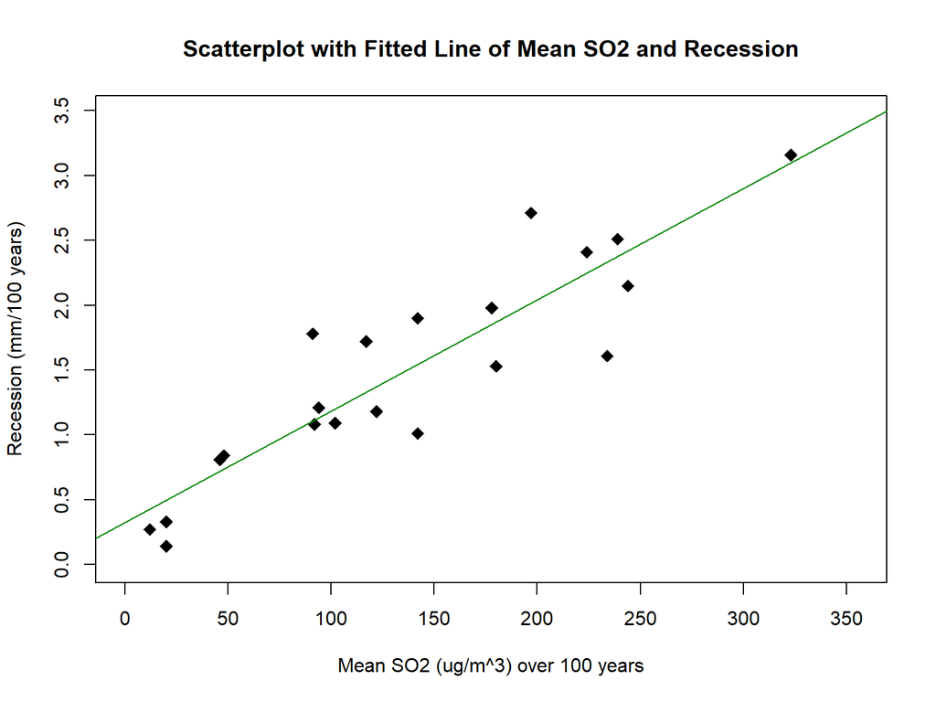

There does indeed seem to be a clear linear relationship between $SO_2$ concentrations and tombstone recessions.

# Checks on Validity

### Normality of Error Distribution

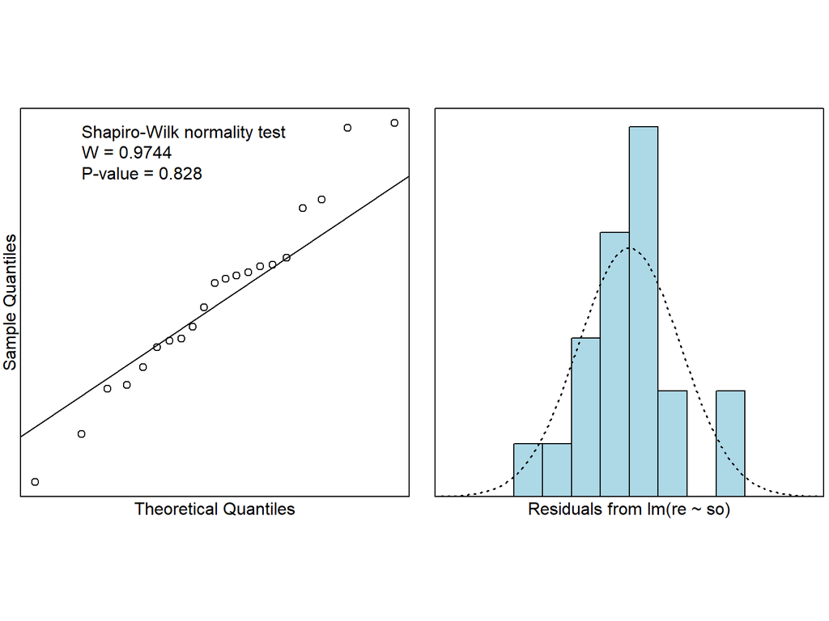

- Error distribution appears to be normal
- P-value of the error distribution is 0.828
- Error is distributed normally. $\epsilon \sim N(0,\sigma^2)$

# Data Analysis

### Residual Data

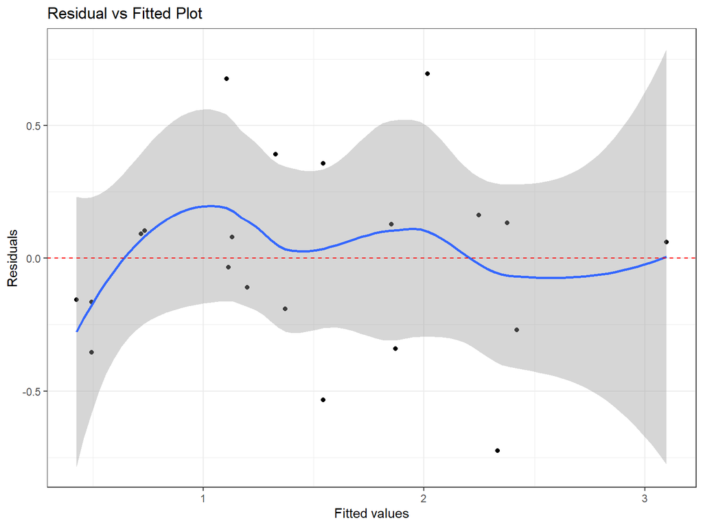

Using a residual vs fitted plot we can see a uniformity about 0 of the residuals. This information tells us that there is no non-uniform and significant deviation from the fitted line from the model.

# Data Analysis

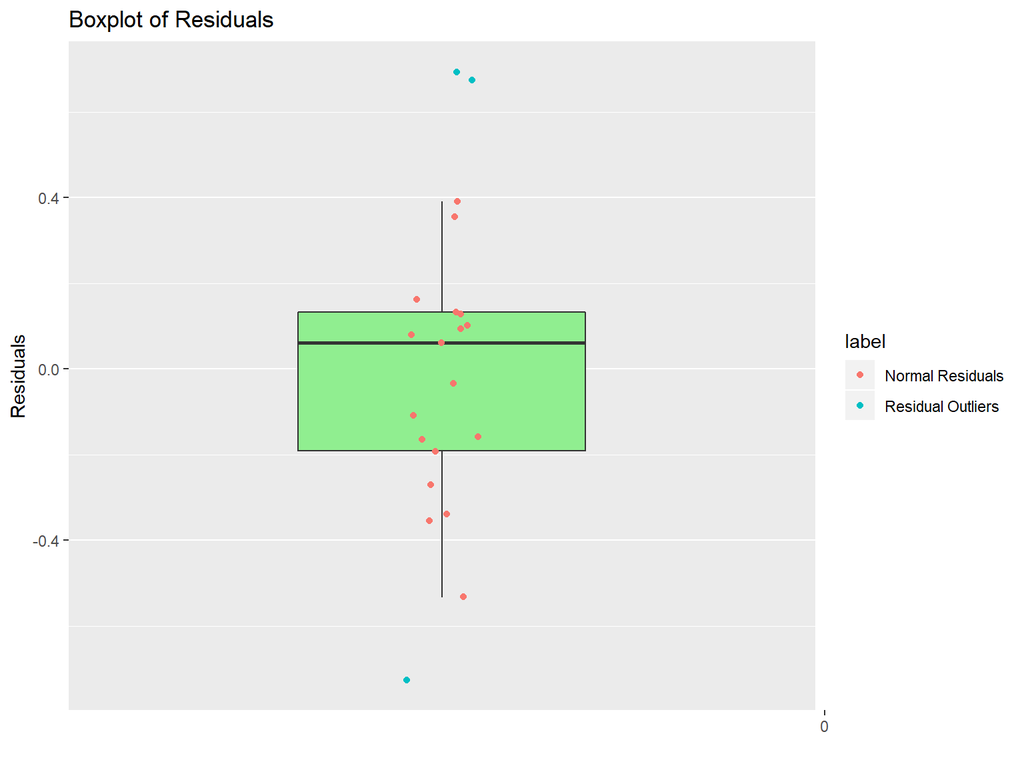

Here we can see how many outlier residuals we actually have.

# Data Analysis

### Plot of Residuals

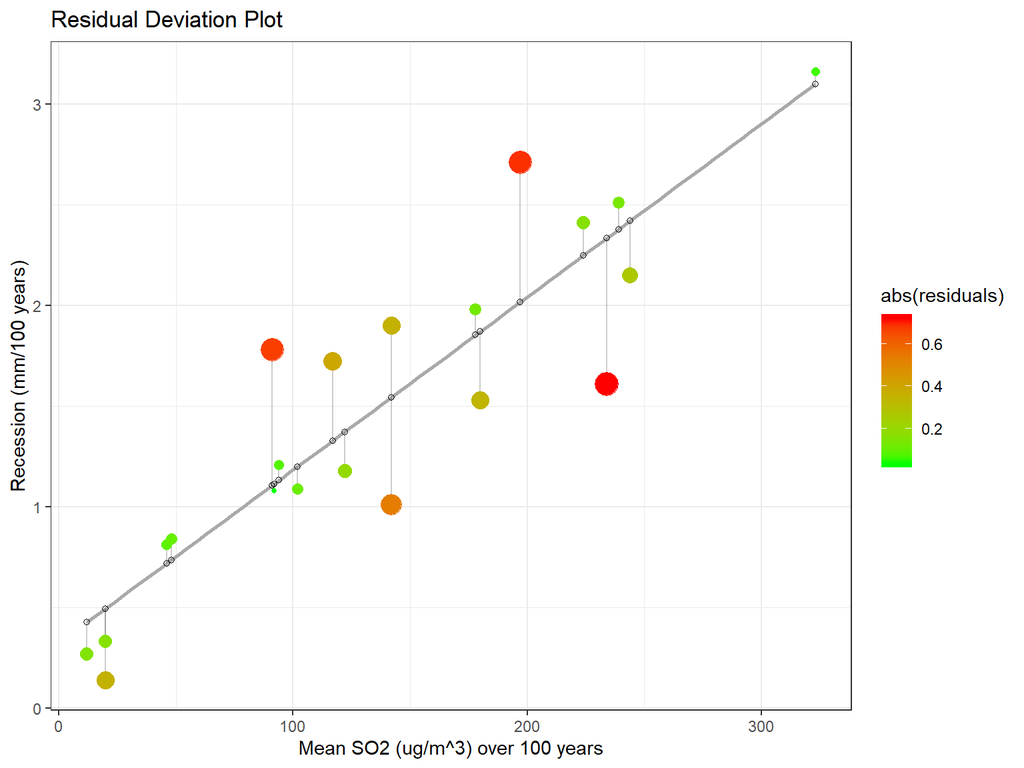

This graph gives us a visual representation of the data residuals about the fitted line. We are able to see specific datapoints in which there are high residual distances. This information gives us the RSS (residual sum of squares), the predicted deviations from the fitted line.

# Data Analysis

### Plot of Means

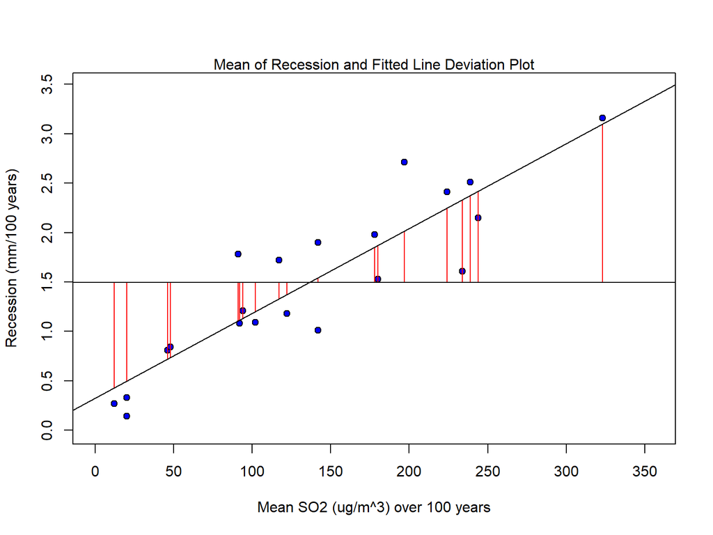

# Data Analysis

### Means with Total Devaitions

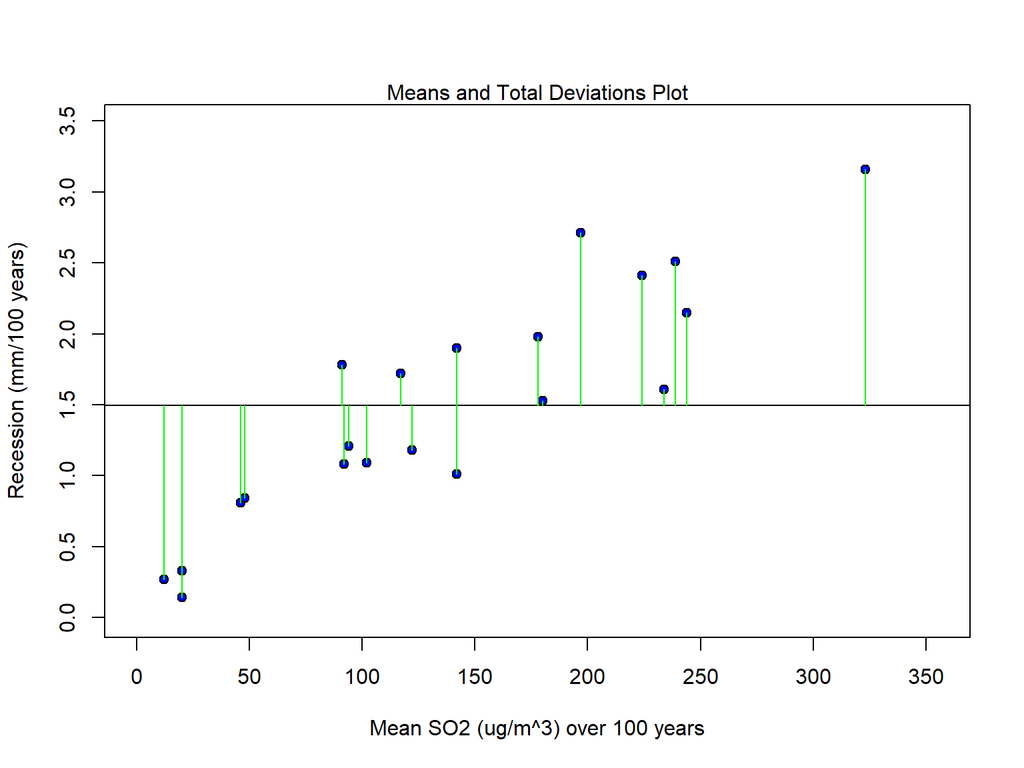

From this graph we can see a visual representaion of total deviation from the mean recession amount. This gives us an idea about distance from the mean line in relation to mean $SO_2$ concentrations. This provides us with the total sum of squares (TSS).

# Data Analysis

```r
RSS=with(tb,sum((re-yhat)^2))
RSS
```

```
## [1] 2.53143
```

```r
MSS=with(tb,sum((yhat-mean(re))^2))
MSS
```

```
## [1] 10.90307
```

```r
TSS=with(tb,sum((re-mean(re))^2))
TSS
```

```
## [1] 13.4345
```

```r
MSS/TSS
```

```
## [1] 0.8115724
```

Our $R^2$ value is 0.8116, showing a well developed linear trend.

# Cooks Distance Analysis

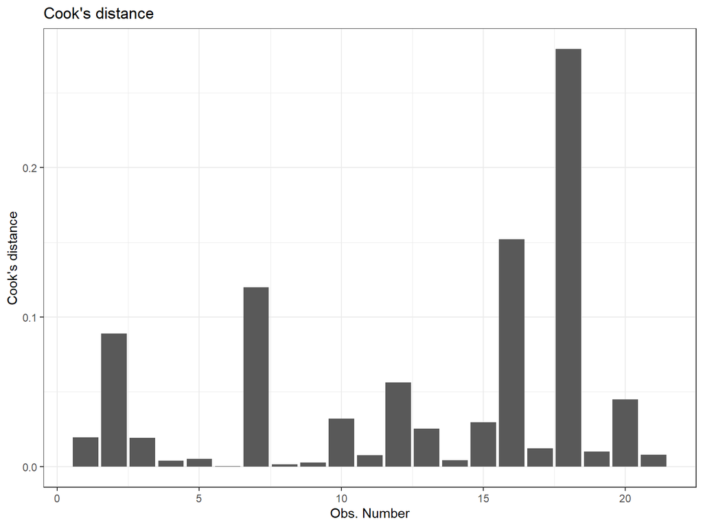

# Summary of Dataset without 18th Data Point

```
##
## Call:
## lm(formula = ree ~ soo, data = tb2)
##
## Residuals:
##     Min      1Q  Median      3Q     Max
## -0.5750 -0.1613 -0.0046  0.1045  0.6607
##
## Coefficients:
##              Estimate Std. Error t value Pr(>|t|)
## (Intercept) 0.2883429  0.1377363   2.093   0.0507 .
## soo         0.0091315  0.0008851  10.317 5.52e-09 ***
## ---
## Signif. codes:  0 '***' 0.001 '**' 0.01 '*' 0.05 '.' 0.1 ' ' 1
##
## Residual standard error: 0.3284 on 18 degrees of freedom
## Multiple R-squared:  0.8553, Adjusted R-squared:  0.8473
## F-statistic: 106.4 on 1 and 18 DF,  p-value: 5.516e-09
```

# Summary of Original Dataset

```
##
## Call:
## lm(formula = re ~ so)
##
## Residuals:
##      Min       1Q   Median       3Q      Max
## -0.72384 -0.19138  0.06136  0.13320  0.69412
##
## Coefficients:
##              Estimate Std. Error t value Pr(>|t|)
## (Intercept) 0.3229959  0.1521958   2.122   0.0472 *
## so          0.0085933  0.0009499   9.046 2.58e-08 ***
## ---
## Signif. codes:  0 '***' 0.001 '**' 0.01 '*' 0.05 '.' 0.1 ' ' 1
##
## Residual standard error: 0.365 on 19 degrees of freedom
## Multiple R-squared:  0.8116, Adjusted R-squared:  0.8017
## F-statistic: 81.83 on 1 and 19 DF,  p-value: 2.579e-08
```

```
## (Intercept)          so
## 0.322995899 0.008593333
```

# Model Predictions

The creation of these models gives us a very powerful tool to predict likely conditions in the future. We will predict what the amount of recession will be in tombstones over a 100 year period with mean $SO_2$ concentrations at 150, 250, and 500 (ug/m^3).

```r
recession = predict(tb.lm, data.frame(so=c(150,250,500)))
recession
```

```
##        1        2        3
## 1.611996 2.471329 4.619662
```

# Conclusion

In conclusion, there does seem to be a direct linear relationship between $SO_2$ concentrations and rate of recession. $SO_2$ concentrations in the atmosphere are put in place through many processes, but especially the burning of coal. As these concentrations increase over periods of time, the loss of marble tombstones through weathering will be quite large. It only takes a very small amount of recession to make a tombstone illegible. When that happens, a person is truely gone and forgotten. The burning of coal and fossil fuels is a necessity though, if we value energy and electricity, at least for the near future. However, as has already begun in the modern era, the transition from marble tombstones to harder and more durable rock types is necessary to preserve the names and legacies of the deceased.

# References

Meierding, T. C. (1993). Marble Tombstone Weathering and Air Pollution in North America. Annals of the Association of American Geographers, 83(4), 568–588. doi: 10.1111/j.1467-8306.1993.tb01954.x

Mendenhall, William M., and Terry L. Sincich. 2016. Simple Linear Regression. 6th ed. Florida, USA: Taylor & Francis Group, LLC.